# RNA-seq Data Analysis and Interpretation

RNA-seq Data Analysis and Interpretation

Objectives: Transcriptome exploration forms the basis of genome’s structural and functional understanding. Nowadays as NGS has greatly accelerated in improvement, RNA-Seq has taken the throne as the center of transcript analysis. RNA-Seq can elucidate mutation-associated genes, alternative splicing analysis, fusion gene discovery, antisense transcript and de novo transcript discovery, and RNA editing analysis, and much more. It has multitude of applications in transcriptome analysis. However, you must first align short reads of fasta(or fastq) files, perform variant calling, do data processing to build the genomic expression profile. And these methods for NGS data undergo different algorithms and computational procedures from those of microarray data. You also gotta have a certain depth of knowledge in biology for transcript analysis at sequence level.

# I. Introduction

Transcriptome (the totality of RNA transcripts) = mRNA + non-coding RNA (lincRNA, anti-sense, miRNA-stRNA, siRNA, piRNA, rasiRNA (functional RNAs), tRNA (non-functional RNA))

RNA-seq sequences cDNAs at nucleotide level. Transcripts’ various structural patterns like splicing patterns are pretty hard to be elucidated by microarray data. Also microarray cannot quantify what isn’t mapped already, that is, no probe exists for the particular transcript to hybridize to. NGS tech has some advantages to tiling microarray in terms of base-level resolution, detection of various isoforms, etc.

| Technology | Tiling microarray | RNA-Seq |
| --- | --- | --- |
| Principle (Technology) | Hybridization | High-throughput Sequencing |
| Resolution | From several to 100 bp | Single base |
| Reliance on genomic sequence | Yes | In some cases |
| Background noise | High | Low |
| Dynamic range to quantify gene expression level | Up to a few-hundredfold | >8,000-fold |
| Distinguish different isoforms | Limited | Yes |
| Distinguish allelic expression | Limited | Yes |
| Required amount of RNA | High | Low |
| Cost for mapping transcriptomes of large genomes | High | Relatively low |

(This table was generated by [Tables Generator](https://www.tablesgenerator.com/markdown_tables#).)

Other ways of high-throughput RNA analysis are [SAGE](https://en.wikipedia.org/wiki/Serial_analysis_of_gene_expression) (serial analysis of gene expression) and [MPSS](https://en.wikipedia.org/wiki/Massively_parallel_signature_sequencing) (massively parallel signature sequencing). In SAGE, RNA -> stable ds cDNA. For each gene, after a specific enzyme digestion, “tag” fragments associated particular genes respectively are generated (11 nucleotides) and these fragments are concatenated (ligated) to make concatenated reads. Then those reads are sequenced using long-read Sanger sequencing. These sequences are deconvoluted[^1] to find out the frequency of each tag. Tag frequency in turn can be used to report on a transcription of the gene that the tag originated. SAGE produces sequences in a digital method, instead of analogue signal used by fluorescence hybridization by microarrays. However SAGE also has its shortcomings that it cannot discover splicing patterns and novel genes that are isoforms of known genes. It cannot detect low-expressed RNA.

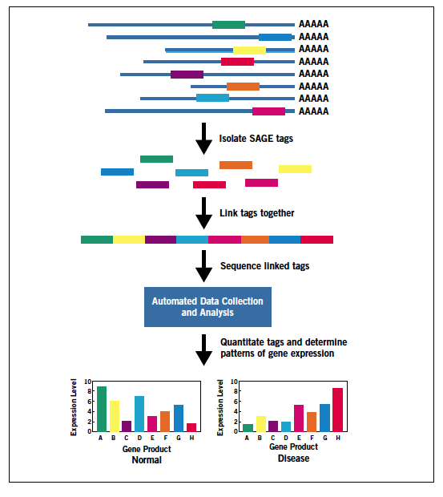

MPSS is similar to SAGE in that it produces data that can quantify mRNA transcripts.

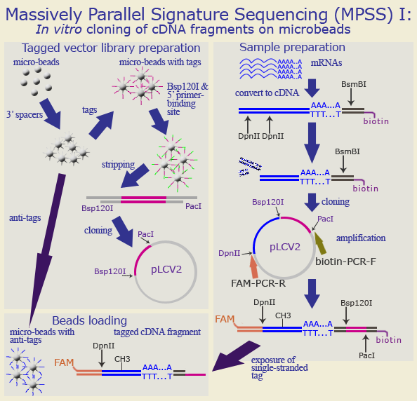

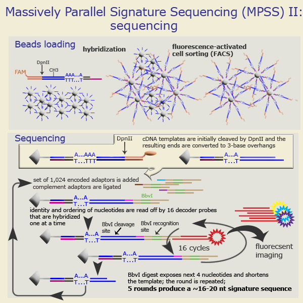

EST (Expressed Sequencing Tag) has also been used as a core technique for building reference transcriptome, but it also has its limitations.

Tiling array that incorporates continuous microarray probes can be used in novel gene discovery and exon discovery. However, it requires **A LOT** of RNA and has shortcomings ni its sensitivity and specificity. Also splicing pattern isn’t analyzable in tiling array.

Now, RNA-seq has clear advantages over the forementioned analysis techniques. You can take RNA-Seq data and with only one experiment (sequencing) a researcher can analyze it for a variety of applications including discovery of mutation genes, alternative splicing, fusion genes, anti-sense transcripts, novel transcript discovery, etc.

# II. Transcriptome Sequencing via RNA-Seq

RNA-Seq uses deep-sequencing technology. Deep sequencing means a read is sequenced multiple times. RNA is prepped (mini-prep, perhaps. prepping is same as extraction) and converted into cDNA fragments with adapters at the ends. Then it’s ammplified via different types of PCR according to the platform. Single-end sequencing or pair-end sequencing results in large amount of data of short reads. Short read lengths differ by technology and platform, but it’s around 30~400 base pairs long. With the read data (fasta, fastq) we map our reads to the reference genome and make alignments to get sam or bam file. These mapped data are then assembled to form a whole genome-level transcriptome map. With such data we can proceed to gene-level mutational study, gene expression study, and much more transcript-related analyses.

The detailed process goes along the line of soemthing like this:

1. RNA is extracted from the sample by prepping and we first ensure RNA integrity by various methods like Lab-on-a-Chip assay (Agilent)
2. RNA molecules are fragmented and reverse transcribed by reverse-transcriptase to make cDNA library.
3. One can attach **“barcodes”** that correspond to each sample as identifier (ID) and sequence multiple samples simultaneously to reduce cost and decrease technical deviations (bias in data due to technical artifacts) between sequencing sessions. This technique is called **(sample )multiplexing** or **multiplex sequencing**. Refer to this [YouTube video](https://www.youtube.com/watch?v=hgSoJiOoSQQ) on Illumina multiplexing.

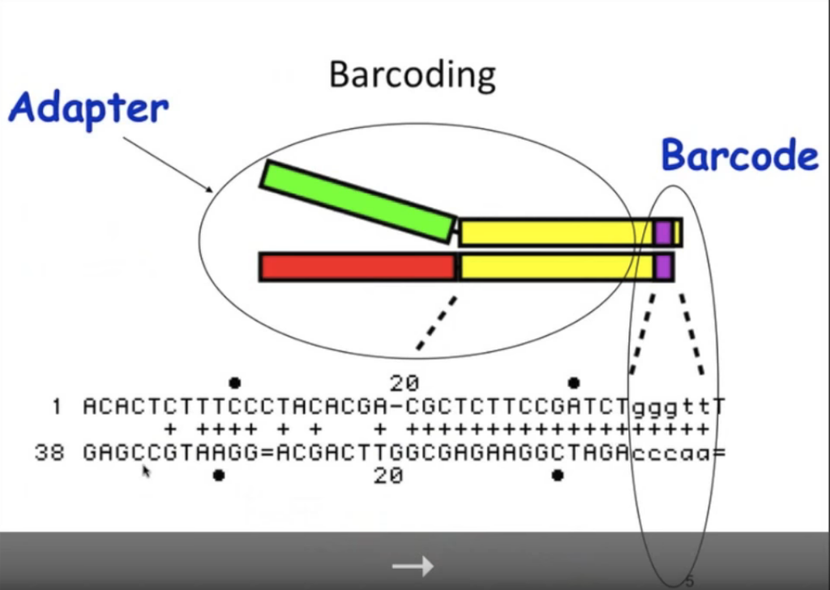

4. Then the miniscule amount of RNA (cDNA) is amplified by PCR.
5. Amplicon is then sequenced by sequencers like Illumina HiSeq, Ion Torrent PGM (Personal Genome Machine), Proton, or S5.
6. The short reads are demultiplexed by barcodes into FASTQ file.
7. [FastQC](http://www.bioinformatics.babraham.ac.uk/projects/fastqc/) evaluates quality of each read. Here low quality reads are removed by a cutoff standard.

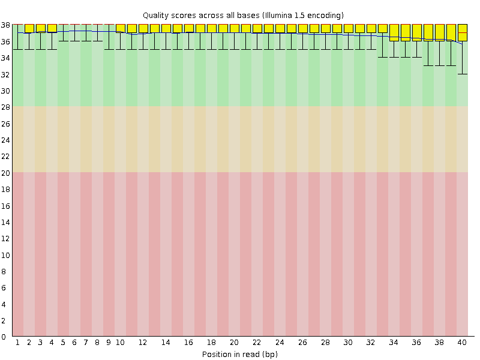

*Good Quality Read*

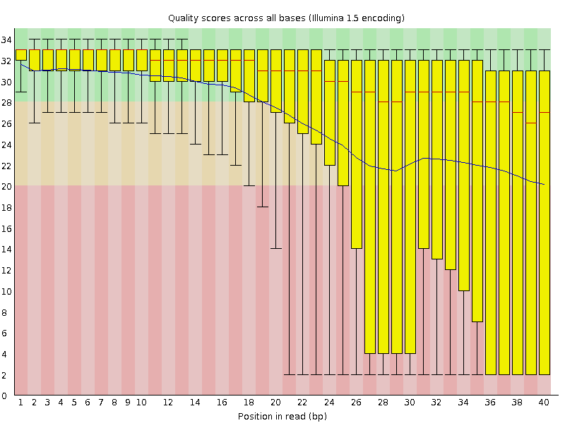

*Bad Quality Read*

# III. Transcript Read Alignments to Reference Genome (Resequencing)

Now RNA-Seq data must be mapped to the reference genome. At other times, one can use the reads as contigs to make the de novo assembly. There are numerous mapping tools for RNA-Seq like ELAND, SOAP, MAQ, BWA, etc. Transcript short reads’ exon junction or poly (A) end must also be mappable (where exons are joined together with introns removed, and poly A tails must be recognized as such). TopHat and other tools are available for this job. For more precise and accurate exon junction mapping, some tools may consider GT-AG two base pattern recognition info. (Possibly hidden markov model)

*When Genome Reference is Present.*

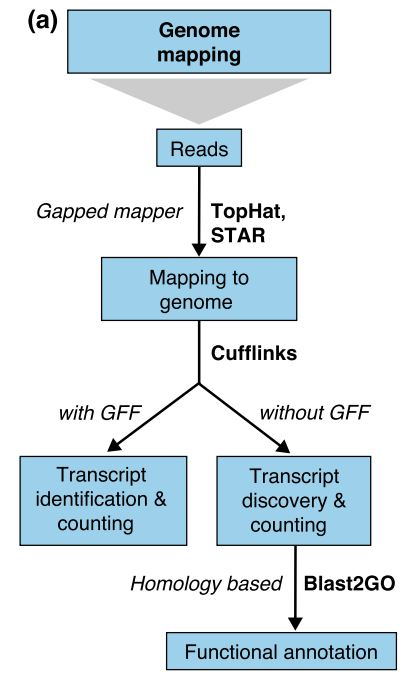

*When Transcriptome Reference is Present*

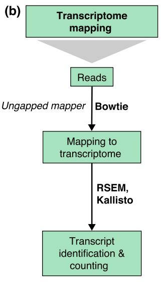

*When No Reference is Present*

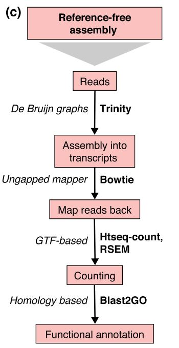

A common problem in short read alignment is multi-matching problem. Many of the reads align to and are mapped to multiple sites of reference genome (so called **multi-mapped reads in RNA-seq**. Refer to this article called [Handling multi-mapped reads in RNA-seq](https://www.sciencedirect.com/science/article/pii/S2001037020303032) for more info. This is a serious problem that may lead to faulty and incorrect transcriptome structure. One solution is considering the read number that are mapped to the regions that are adjacent to short reads. This method works alright for low-copy repeat sequence, but when it comes to high-copy repeat sequences with long repeating sequence the complexity of the problem increases. You could use long-read sequencing technologies like 454 to tackle this multi-matching problem. Also you could use paired-end sequencing that uses two short reads that are about 200~500 base pairs apart and sequence them from opposite direction as a possible solution. Many companies are competing against each other to achieve better performance of their sequencing products, but researchers may have to cleverly integrate different technologies in order to obtain high quality sequence data.

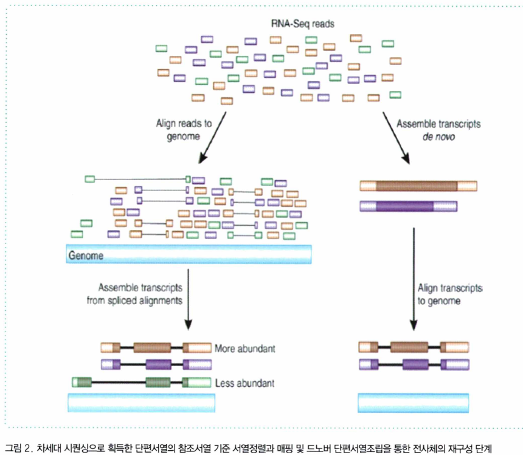

Mapping to reference genome and then the reads are clustered by the amount of reads. According to abundance, some reads are considered to belong to one transcript and other reads are considered to belong to other transcript.

Assembling transcripts de novo is also possible. After the transcripts are mapped, they are aligned to the reference genome.

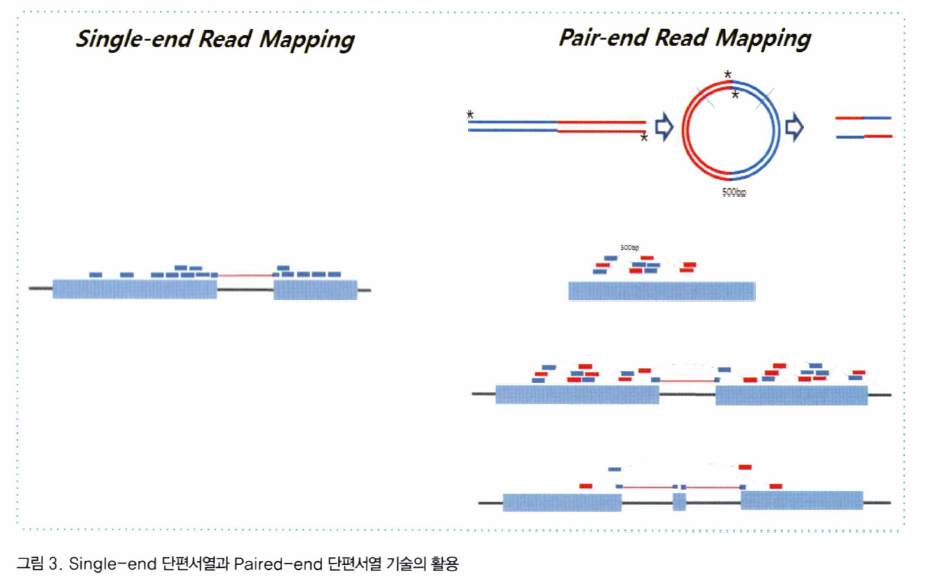

* *Note: It seems that the figure above describes mate paired-end sequencing.*

# IV. Measuring Transcript Expression Level

Measuring how much an mRNA (or any other RNAs) is expressed is achieved by computing the mapping coverage. For valid comparison among different gene expression levels, normalization is required. For example, when there are same number of shorter and longer reads (same “read count”) to two different genes, the shorter one is expressed more.

[figure not shown]

This is corrected by RPK for comparison among reads. To be able to compare read counts across isoforms, we divide the **counts** by the isoform **length**. It is also customary to multiply the number 1000, obtaining *reads per kilobase.*

Therefore RPK is calculated as

$$RPK_i = 10^3 \cdot \frac{n_i}{l_i}$$

where $n$ is read count for each read and $l$ is length of that read.

[figure not shown]

Now, the total fragment count may vary across experiments. Therefore, to compare counts across experiments, further normalization by total fragment count is required (usually expressed in millions). Thus, *reads per kilobase per million* is computed as

$$RPKM_i = 10^9\cdot\frac{n_i}{l_i\cdot\sum_jn_j} = 10^9\cdot\frac{\textrm{number of mappable reads}}{\textrm{(the sum of the exons in base pairs)(the total number of mappable reads in the experiment)}}$$
, where $n$ is read count, $l$ is length of that read, and also for normalization over the total count number $\sum_jn_j$ represents the total read count.

If isoforms need not be compared, one can simply use RPM (reads per million counts) instead of RPKM (reads per kilobase and million counts).

TPM (transcript per million) can measure relative abundance of transcripts. To estimate it from the count data, notice that the RPK values are proportional to the abundances of isoforms within a single experiment.

[figure not shown]

In the above picture, red transcript’s RPK and RPKM values are same in both tissue 1 and 2. Formula for $RPKM_i$ only considers the length of isoform i only. However, the length of other isoforms clearly affect the relative number of isoform i’s fragments because in tissue 1, red is significantly underexpressed compared to yellow, while in tissue 2, red and green are about equally expressed. TPM is expressed with the formula below.

$$TPM_i = 10^6\cdot\frac{RPK_i}{\sum_jRPK)j} = 10^6\cdot\frac{n_i/l_i}{\sum_jn_j/l|j}$$

Rest of the in-depth topics (relative vs. absolute expression -> add a known amount of artificial RNA or DNA, Dangers of relative expression -> when absolute level rises, relative abundance might be different and lead to believe that other isoform decreases.) on RNA-seq analysis and normalization terminology is at the following link: https://ro-che.info/articles/2016-11-28-rna-seq-normalization.

So what’s FPKM then? If RPKM is expression unit on the gene level, FPKM is the expression unit on the transcript level.

- Reads per kilobase of exon model per million mapped fragments
- Paired-end RNA-Seq experiments produce two reads per fragment, but that doesn’t necessarily mean that both reads will be mappable. If we were to count reads rather than fragments, we might double-count some fragments but not others, leading to a skewed expression value.

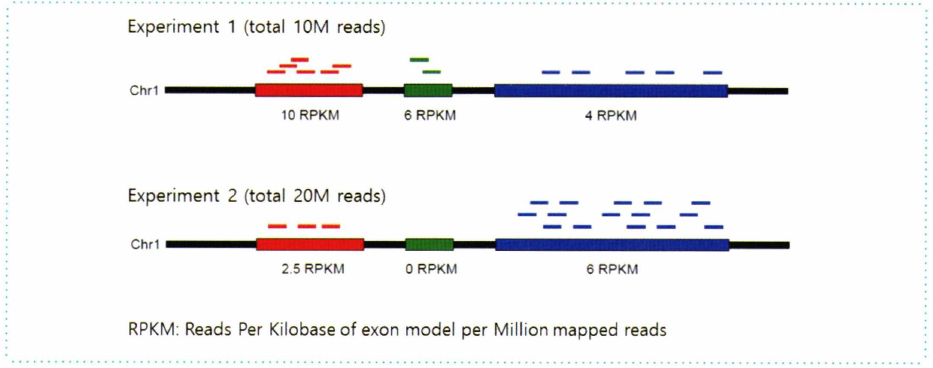

Workflow of RNA-seq data analysis goes like this:

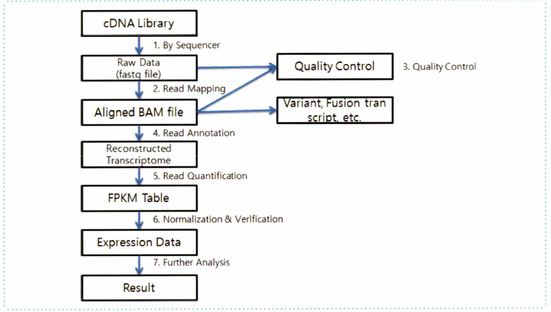

# V. Differential Expression Analysis

Differential expression analysis methods have been developed for comparing two groups’ RNA-seq expression data. The list of such softwares includes Cuffdiff, baySeq, DESeq, DEGseq, edgeR. These softwares analyze which genes are statistically significantly show difference in expression in each sample from short read alignment that have been mapped. Cufflink can even calculate isoform level expression. Various statistical methods like Joint Poisson model[^2], EM algorithm[^3], Bayesian inference[^4] are used to infer expression level of different isoforms.

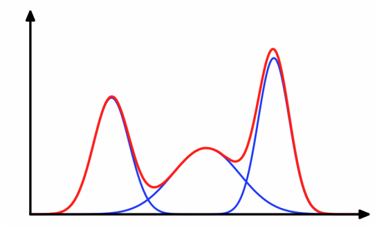

*Gaussian Mixture Model used in EM Algorithm*

Not sure as to what all these statistical terminology means, but in the meantime, I will work towards learning the concepts by myself.

Unlike microarray data, RNA-seq differential expression analysis has its own normalization and differential expression analysis steps (like DESeq, edgeR), and they are performed internally. Information pertaining to gene expression like RPKM are employed as a standard way to report expression level, but there is a tendency thta it’s not directly used in differential analysis. RNA-seq data is not an intensity signal but discrete “count”, data analysis with RNA-seq data usually involves such characteristics. For example, supposed that transcript with 50000 base length ($l_i$) has 1000 count of expressed transcript in condition A and 700 count of expressed transcript in condition B. And also assume that transcript with $l_i$ = 500 nucleotide is expressed 10 and 7 in condition A and B respectively. Both cases have the same RPKM, but it would be reasonable to put more confidence in the 1000 count and 700 count case.

# VI. Identifying Alternative Splicing

RNA-seq not only can quantitatively count the reads that are mapped to the already known splicing junctions, but also identify unknown splicing junctinos. By detecting the short reads that are mapped to exon junction can lead to finding the splicing region, and de novo assembly can lead to discovery of alternative splicing products that have different combinations of exons. [Morin, et al., 2008](https://www.future-science.com/doi/abs/10.2144/000112900) found 31618 splicing phenomena out of known 284873 splicing phenomena in HeLa S3 cell line RNA-seq analysis, and also found 379 novel splicing phenomena. [Sultan et al., 2008](https://science.sciencemag.org/content/321/5891/956.abstract) found total of 94241 splicing exon junctions including 4096 of previously unknown results from human fetal kidney and B-cell cell lines. The results indicate that out of various alternative splicing types, exon skipping is the most prevalent.

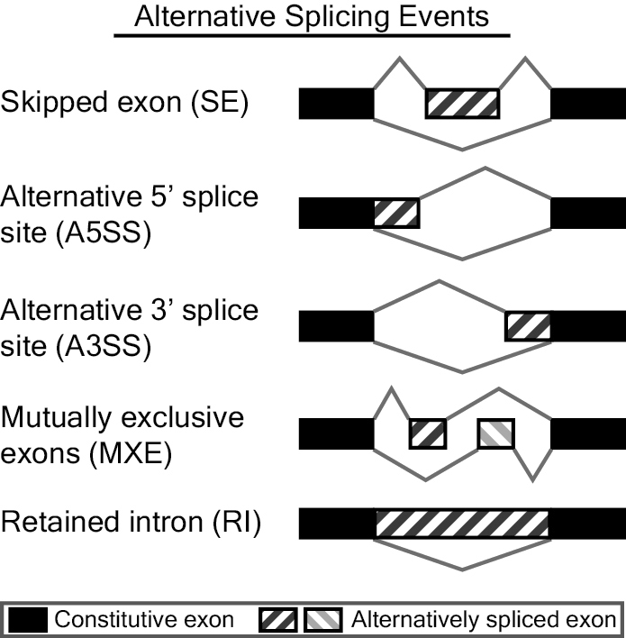

*Alternative splicing types detected by MATS. Alternatively spliced exons are designated as striped. (Park et al., Methods Mol Biol. 2013)*

# VII. Sequence Assembly

[Cufflinks](http://cole-trapnell-lab.github.io/cufflinks/) is a representative sequence assembly program and it receives [TopHat aligner](https://ccb.jhu.edu/software/tophat/index.shtml)’s mapped results, which can align short reads to exon junctions. However, its core functionalities are mostly more accurate and much more efficient to perform in [HISAT2](https://daehwankimlab.github.io/hisat2/) now, that TopHat is under low-maintenance, low-support stage. You can visit [here](https://www.ncbi.nlm.nih.gov/pmc/articles/PMC2672628/) to read TopHat original article.

If reference genome is incomplete or some parts of it are omitted, you can use de novo assembly softwares like MIRA, Oases, ABySS.

For the time being, many eukaryotic reference genomes are known for organisms like human and yeast, but there are many other species whose genome are not studied throughly enough and also there are previously unknown transcripts being discovered day by day. RNA-Seq has nucleotide-level resolution (awesomely high resolution!) and therefore is useful for accurately identifying novel isoforms, transcript borderline, and effectively inferring correct exon-intron structures. Furthermore, it can be applied to detection of antisense transcript that exhibit functions like siRNA (RNA interference) for regulation. For example, we can identify transcript pairs that are antisense to particular regions of genomic sense sequence.

# VIII. RNA Editing Analysis

- Base modification editing (substitution editing; same effect as substitution): Results in base modification and changes an encoded nucleotide into a different nucleotide, without changing the overall length of the RNA and thus retaining the open reading frame. Most representative example of base modification is substitution from adenosine to inosine by ADAR (Adenosin DeAminase acting on RNA). RNA-seq technology unveiled more than 14 types of such substitution phenomena like C to U in apolipoprotein B (apoB) editing. (In summary, there are mostly three types: A to I, A to U, C to U)

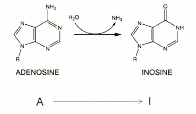

- Insertion/deletion editing: Involves the insertion or deletion of nucleotides and actually changes the length of the target RNA.

RNA editing is known to occur widely throughout intron, 5’-UTR, 3’-UTR, non-coding RNA, coding region, and more, and a lot of it is concentrated in Alu elements (Alu repeats). Alu element is a short stretch of DNA originally characterized by the action of the *Arthrobacter luteus (Alu)* restrictino endonuclease. These are the most abundant transposable elements, over one million copies dispersed throughout human genome. Derived from the small cytoplasmic 7SL RNA, a component of the signal recognition particle, Alu elements are highly conserved within primate genomes and originated in the genome of an ancestor of Supraprimates. Alu insertions have been implicated in several inherited human diseases and in various forms of cancer. RNA editing impacts functions of many transcripts, particularly alternative splicing and gene expression. It’s a form of biological genetic diversity where even at post-transcriptional level, distortion in information can occur.

There are two ways of achieving RNA editing detection:

1. RNA-seq data and DNA-seq data are extracted from the same sample. DNA-seq data probably go through de novo assembly, RNA-seq data maybe as well. Or RNA-seq data might be mapped onto DNA-seq data. Then these two are compared directly to see any difference in sequence, which is an evidence of RNA editing. (Note that RNA editing occurs frequently enough to be detected in a statistically significant manner.)
2. RNA-seq data and DNA-seq data from the same sample are mapped onto the reference genome. We get VCF files of RNA and DNA-seq data and these VCF files are compared to see if there are any systematic differences present in the sequence. (Detect *RNA DNA differences* or RDDs)

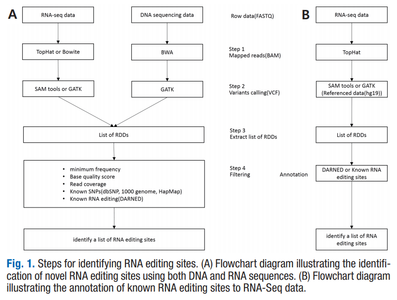

*This flowchart illustrates the steps in identifying novel RNA editing sites and annotation of known RNA editing sites. From http://www.snubi.org/~juhan/pubFiles/RNAEditing.pdf

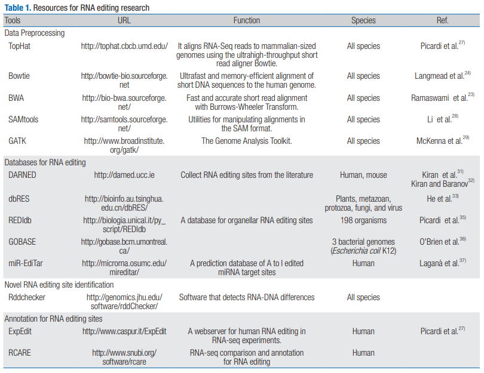

[^1]: Deconvolution in mathematics means the algorithm-based process to enhance signals from noise.
[^2]: https://en.wikipedia.org/wiki/Compound_Poisson_distribution
[^3]: http://bjlkeng.github.io/posts/the-expectation-maximization-algorithm/
[^4]: https://en.wikipedia.org/wiki/Bayesian_inference